# Learn You an R

## What is R?

### "Data Science"

### "Statistics"

## What is R?

[figure not shown]

## What is R?

[figure not shown]

## What is R?

- Implementation of / Successor to "S"
  - Created ~ the same time as C
- ~30yr Old
- Actively Used by Thousands
  - R powers tons of data-science stuff in many companies

## On to the Code!

# Basics

R syntax is mostly pretty normal.

**Booleans**

```r
TRUE
FALSE
```

TRUE

FALSE

**Numbers**

```r
-1
1
1.2
```

-1

1

1.2

**Strings**

```r
"I am a string"
'single quotes work too'
```

'I am a string'

'single quotes work too'

**Math**

```r
1 + 2
2^8
5 %% 3
```

3

256

2

**Variables**

```r
my_variable <- 42
my_variable
```

42

**Functions**

```r
print("I'm a function")
```

```
[1] "I'm a function"
```

```r
# Make your own!
say_hello <- function(name) {
    print(paste("Hello", name))
}
say_hello("Hacker Refactor")
```

```
[1] "Hello Hacker Refactor"
```

**Control Flow**

```r
if (8 %% 2 == 0) {
    print("8 is even")
}
```

```
[1] "8 is even"
```

```r
my_variable
while (my_variable > 0) {
    my_variable <- my_variable - 1
}
my_variable
```

42

0

```r
sum <- 0
for (i in 1:10) {
    sum <- sum + i
}
sum
```

55

# Vectors

In R, everyting is a vector.

"Vector" is R's name for:

- "lists" in Python
- "arrays" in Java, C, js, C#, etc
- "vectors" in C++

All these things we just talked about were vectors.

```r
length(10)
length("hello")
length(TRUE)
```

1

1

1

Extend vectors with "combine", spelled `c`

```r
c(1, 2, 3, 4, 5)
c("a", "b", "c")
```

1. 1

2. 2

3. 3

4. 4

5. 5

1. 'a'

2. 'b'

3. 'c'

```r
length(c(1, 2, 3, 4, 5))
```

5

Remember this is just concatenating existing vectors

```r
c(1, c(2, 3), 4)
```

1. 1

2. 2

3. 3

4. 4

Everything is a vector, so all operators are defined over vectors

```r
c(1, 2, 3) * 5
2 ^ c(1, 2, 3, 4, 5, 6, 7, 8)
```

1. 5

2. 10

3. 15

1. 2

2. 4

3. 8

4. 16

5. 32

6. 64

7. 128

8. 256

Including multi-element vectors

```r
c(1, 2) + c(3, 4)
```

1. 4

2. 6

This includes general "broadcasting"

```r
c(1, 2, 3, 4) * c(100, -1)
```

1. 100

2. -2

3. 300

4. -4

# Vector Indexing

This is where things get really fun.

**Basic Indexing**

```r
example_vector <- c(1, -1, 2, 8, 3, -5, 100)
```

Indexing uses `[..]` like in most languages

```r
example_vector[1]
```

1

But... Remember everything is a vector

```r
example_vector[c(1, 3, 5, 7)]
```

1. 1

2. 2

3. 3

4. 100

Negative indexes act like a filter

```r
example_vector[-7]
```

1. 1

2. -1

3. 2

4. 8

5. 3

6. -5

**Bool Indexing**

```r
example_vector <- c(1, -1, 2, 8, 3, -5, 100)
```

Include/exclude each element

```r
example_vector[c(TRUE, FALSE, TRUE, FALSE, TRUE, FALSE, TRUE)]
```

1. 1

2. 2

3. 3

4. 100

Vectors are repeated, useful for "every other" type filters

```r
example_vector[c(TRUE, FALSE)]
```

1. 1

2. 2

3. 3

4. 100

**Bool Filters**

```r
example_vector <- c(1, -1, 2, 8, 3, -5, 100)
```

All Negatives

```r
example_vector < 0
```

1. FALSE

2. TRUE

3. FALSE

4. FALSE

5. FALSE

6. TRUE

7. FALSE

```r
example_vector[c(FALSE, TRUE, FALSE, FALSE, FALSE, TRUE, FALSE)]
```

1. -1

2. -5

```r
example_vector[example_vector < 0]
```

1. -1

2. -5

**Bool Filters**

```r
example_vector <- c(1, -1, 2, 8, 3, -5, 100)
```

Outliers (> 90th Percentile)

```r
example_vector[example_vector > quantile(example_vector, .9)]
```

100

Non-Outliers (inverse)

```r
example_vector[!(example_vector > quantile(example_vector, .9))]
```

1. 1

2. -1

3. 2

4. 8

5. 3

6. -5

# Lists

The last basic thing we need to know.

Lists are kind-of like dictionaries/Hashes/Associative Arrays

```r
favorite_colors <- list(
    josh = "purple",
    sam = "yellow",
    brenna = "black"
)
favorite_colors
```

**$josh**

'purple'

**$sam**

'yellow'

**$brenna**

'black'

You can index them like a vector by key

```r
favorite_colors[c("josh", "brenna")]
```

**$josh**

'purple'

**$brenna**

'black'

`[[` works more like a standard dictionary lookup

```r
favorite_colors[["josh"]]
```

'purple'

`$` is a shorthand for `[[` if you know the key name

```r
favorite_colors$josh
```

'purple'

Lists can also work like arrays

```r
list(1, 2, 3)
```

1. 1

2. 2

3. 3

They can contain different types though!

```r
list(1, 'a', TRUE)
```

1. 1

2. 'a'

3. TRUE

# Data Frames

The heart and soul of data-analysis in R.

Data frames are a rectangular (think excel) structures for data.

```r
pokemon <- read.csv("pokemon.csv")
head(pokemon)
```

A data.frame: 6 × 51

|  | id <int> | pokedex_number <int> | name <chr> | german_name <chr> | japanese_name <chr> | generation <int> | status <chr> | species <chr> | type_number <int> | type_1 <chr> | ⋯ | against_ground <dbl> | against_flying <dbl> | against_psychic <dbl> | against_bug <dbl> | against_rock <dbl> | against_ghost <dbl> | against_dragon <dbl> | against_dark <dbl> | against_steel <dbl> | against_fairy <dbl> |
| --- | --- | --- | --- | --- | --- | --- | --- | --- | --- | --- | --- | --- | --- | --- | --- | --- | --- | --- | --- | --- | --- |
| 1 | 0 | 1 | Bulbasaur | Bisasam | フシギダネ (Fushigidane) | 1 | Normal | Seed Pokémon | 2 | Grass | ⋯ | 1 | 2.0 | 2.0 | 1.0 | 1.00 | 1 | 1.0 | 1 | 1.0 | 0.5 |
| 2 | 1 | 2 | Ivysaur | Bisaknosp | フシギソウ (Fushigisou) | 1 | Normal | Seed Pokémon | 2 | Grass | ⋯ | 1 | 2.0 | 2.0 | 1.0 | 1.00 | 1 | 1.0 | 1 | 1.0 | 0.5 |
| 3 | 2 | 3 | Venusaur | Bisaflor | フシギバナ (Fushigibana) | 1 | Normal | Seed Pokémon | 2 | Grass | ⋯ | 1 | 2.0 | 2.0 | 1.0 | 1.00 | 1 | 1.0 | 1 | 1.0 | 0.5 |
| 4 | 64 | 50 | Alolan Diglett | Digda | ディグダ (Digda) | 1 | Normal | Mole Pokémon | 2 | Ground | ⋯ | 2 | 0.5 | 0.5 | 0.5 | 0.25 | 1 | 0.5 | 1 | 0.5 | 0.5 |
| 5 | 3 | 3 | Mega Venusaur | Bisaflor | フシギバナ (Fushigibana) | 1 | Normal | Seed Pokémon | 2 | Grass | ⋯ | 1 | 2.0 | 2.0 | 1.0 | 1.00 | 1 | 1.0 | 1 | 1.0 | 0.5 |
| 6 | 65 | 51 | Dugtrio | Digdri | ダグトリオ (Dugtrio) | 1 | Normal | Mole Pokémon | 1 | Ground | ⋯ | 1 | 1.0 | 1.0 | 1.0 | 0.50 | 1 | 1.0 | 1 | 1.0 | 1.0 |

They work a lot like lists, where columns are keys

```r
head(pokemon$name)
length(pokemon$name)
```

1. 'Bulbasaur'

2. 'Ivysaur'

3. 'Venusaur'

4. 'Alolan Diglett'

5. 'Mega Venusaur'

6. 'Dugtrio'

1028

And we can index them like a vector!

```r
grep("Char", pokemon$name)
pokemon$name[grep("Char", pokemon$name)]
```

1. 7

2. 46

3. 50

4. 54

5. 88

6. 727

1. 'Charmander'

2. 'Charmeleon'

3. 'Charizard'

4. 'Mega Charizard X'

5. 'Mega Charizard Y'

6. 'Charjabug'

When paired with indexing, slicing data is easy!

```r
pokemon[grep("Char", pokemon$name),]
```

A data.frame: 6 × 51

|  | id <int> | pokedex_number <int> | name <chr> | german_name <chr> | japanese_name <chr> | generation <int> | status <chr> | species <chr> | type_number <int> | type_1 <chr> | ⋯ | against_ground <dbl> | against_flying <dbl> | against_psychic <dbl> | against_bug <dbl> | against_rock <dbl> | against_ghost <dbl> | against_dragon <dbl> | against_dark <dbl> | against_steel <dbl> | against_fairy <dbl> |
| --- | --- | --- | --- | --- | --- | --- | --- | --- | --- | --- | --- | --- | --- | --- | --- | --- | --- | --- | --- | --- | --- |
| 7 | 4 | 4 | Charmander | Glumanda | ヒトカゲ (Hitokage) | 1 | Normal | Lizard Pokémon | 1 | Fire | ⋯ | 2 | 1 | 1 | 0.50 | 2 | 1 | 1 | 1 | 0.5 | 0.5 |
| 46 | 5 | 5 | Charmeleon | Glutexo | リザード (Lizardo) | 1 | Normal | Flame Pokémon | 1 | Fire | ⋯ | 2 | 1 | 1 | 0.50 | 2 | 1 | 1 | 1 | 0.5 | 0.5 |
| 50 | 6 | 6 | Charizard | Glurak | リザードン (Lizardon) | 1 | Normal | Flame Pokémon | 2 | Fire | ⋯ | 0 | 1 | 1 | 0.25 | 4 | 1 | 1 | 1 | 0.5 | 0.5 |
| 54 | 7 | 6 | Mega Charizard X | Glurak | リザードン (Lizardon) | 1 | Normal | Flame Pokémon | 2 | Fire | ⋯ | 2 | 1 | 1 | 0.50 | 2 | 1 | 2 | 1 | 0.5 | 1.0 |
| 88 | 8 | 6 | Mega Charizard Y | Glurak | リザードン (Lizardon) | 1 | Normal | Flame Pokémon | 2 | Fire | ⋯ | 0 | 1 | 1 | 0.25 | 4 | 1 | 1 | 1 | 0.5 | 0.5 |
| 727 | 856 | 737 | Charjabug | Akkup | デンヂムシ (Dendimushi) | 7 | Normal | Battery Pokémon | 2 | Bug | ⋯ | 1 | 1 | 1 | 1.00 | 2 | 1 | 1 | 1 | 0.5 | 1.0 |

For example, we can grab fire type pokemon

```r
head(pokemon[pokemon$type_1 == "Fire" | pokemon$type_2 == "Fire",])
```

A data.frame: 6 × 51

|  | id <int> | pokedex_number <int> | name <chr> | german_name <chr> | japanese_name <chr> | generation <int> | status <chr> | species <chr> | type_number <int> | type_1 <chr> | ⋯ | against_ground <dbl> | against_flying <dbl> | against_psychic <dbl> | against_bug <dbl> | against_rock <dbl> | against_ghost <dbl> | against_dragon <dbl> | against_dark <dbl> | against_steel <dbl> | against_fairy <dbl> |
| --- | --- | --- | --- | --- | --- | --- | --- | --- | --- | --- | --- | --- | --- | --- | --- | --- | --- | --- | --- | --- | --- |
| 7 | 4 | 4 | Charmander | Glumanda | ヒトカゲ (Hitokage) | 1 | Normal | Lizard Pokémon | 1 | Fire | ⋯ | 2 | 1 | 1 | 0.5 | 2 | 1 | 1 | 1 | 0.5 | 0.5 |
| 22 | 384 | 324 | Torkoal | Qurtel | コータス (Cotoise) | 3 | Normal | Coal Pokémon | 1 | Fire | ⋯ | 2 | 1 | 1 | 0.5 | 2 | 1 | 1 | 1 | 0.5 | 0.5 |
| 23 | 195 | 155 | Cyndaquil | Feurigel | ヒノアラシ (Hinoarashi) | 2 | Normal | Fire Mouse Pokémon | 1 | Fire | ⋯ | 2 | 1 | 1 | 0.5 | 2 | 1 | 1 | 1 | 0.5 | 0.5 |
| 27 | 196 | 156 | Quilava | Igelavar | マグマラシ (Magmarashi) | 2 | Normal | Volcano Pokémon | 1 | Fire | ⋯ | 2 | 1 | 1 | 0.5 | 2 | 1 | 1 | 1 | 0.5 | 0.5 |
| 33 | 197 | 157 | Typhlosion | Tornupto | バクフーン (Bakphoon) | 2 | Normal | Volcano Pokémon | 1 | Fire | ⋯ | 2 | 1 | 1 | 0.5 | 2 | 1 | 1 | 1 | 0.5 | 0.5 |
| 36 | 456 | 383 | Primal Groudon | Groudon | グラードン (Groudon) | 3 | Legendary | Continent Pokémon | 2 | Ground | ⋯ | 2 | 1 | 1 | 0.5 | 1 | 1 | 1 | 1 | 0.5 | 0.5 |

# Stats

The thing everyone knows R for.

R can do basic summary plots

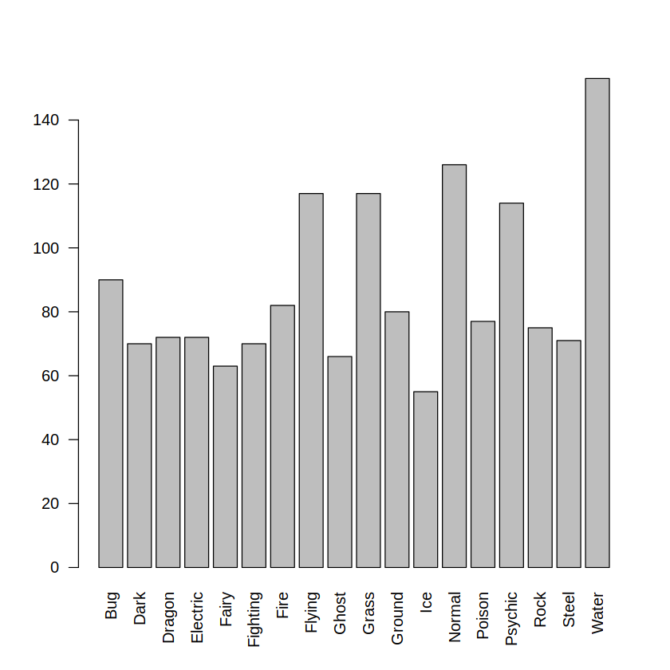

```r
types <- c(pokemon$type_1, pokemon$type_2)
types <- types[types != ""] # Filter unset values.
barplot(table(types), las=2)
```

We can do a simple regression on our pokemon dataset

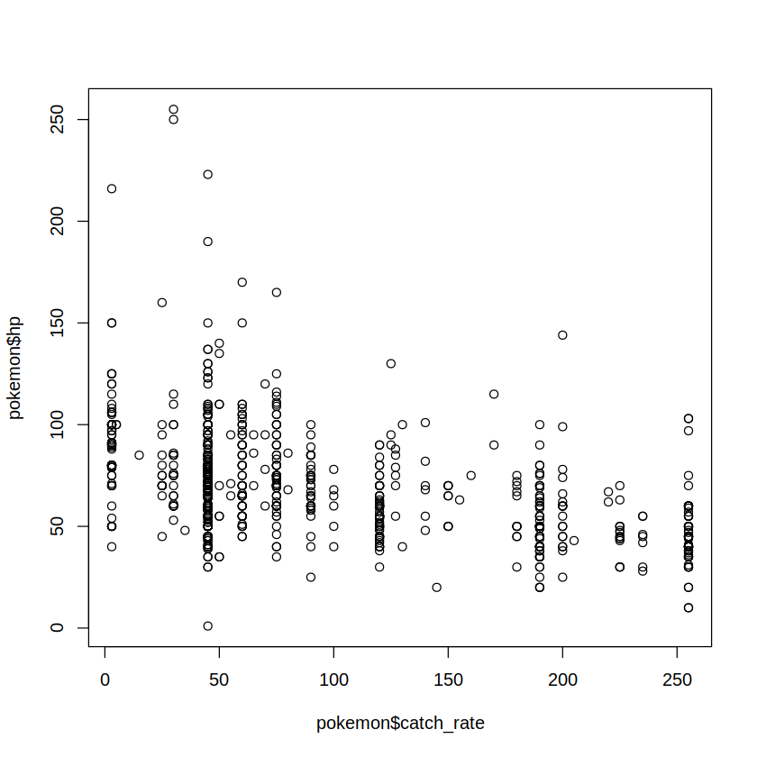

```r
plot(pokemon$catch_rate, pokemon$hp)
```

Looks like, there's a negative correlation between HP and catch rate, we can fit a linear model to the data with `lm`.

```r
regression <- lm(hp ~ catch_rate, data=pokemon)
regression
```

```
Call:
lm(formula = hp ~ catch_rate, data = pokemon)

Coefficients:
(Intercept)   catch_rate
    84.6154      -0.1623
```

And then we can plot our regression against the data.

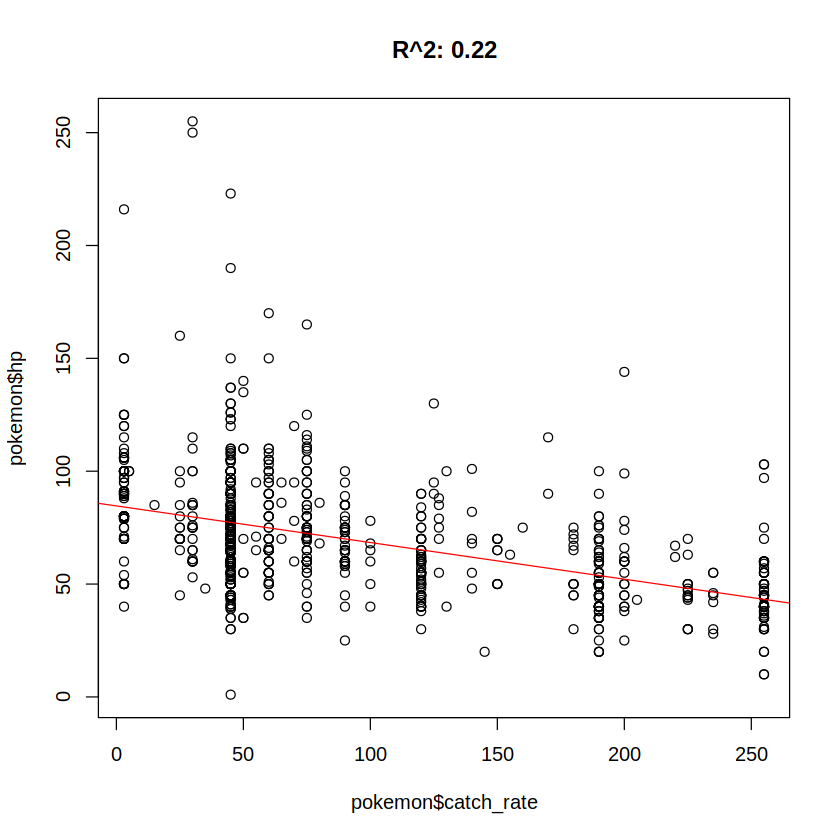

```r
plot(pokemon$catch_rate, pokemon$hp)
abline(regression, col="red")

title(paste("R^2:", format(summary(regression)$r.squared, digits=2)))
```

I was working with a [gamma distribution](https://en.wikipedia.org/wiki/Gamma_distribution)

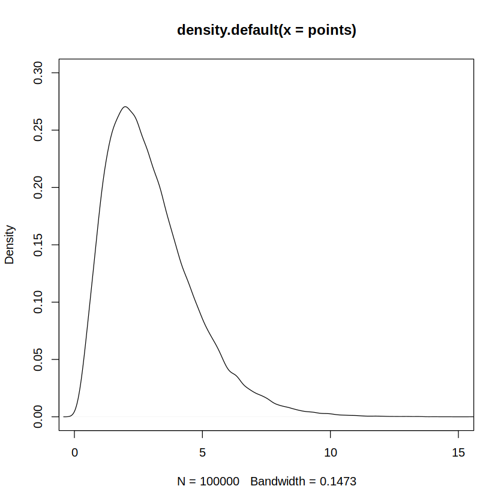

```r
shape <- 3
points <- rgamma(100000, shape)
plot(density(points), xlim=c(0,15), ylim=c(0, 0.3))
```

I was looking for gamma distributions with a specific 90th percentile

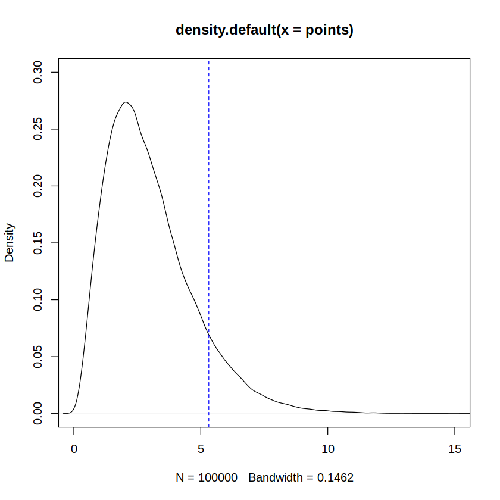

```r
shape <- 3
points <- rgamma(100000, shape)
plot(density(points), xlim=c(0,15), ylim=c(0, 0.3))
abline(v=quantile(points,.9), col="blue", lty="dashed")
```

## How to efficiently estimate quantile function of Gamma distribution

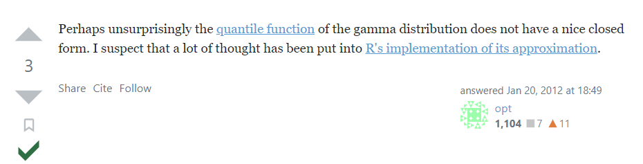

(From https://math.stackexchange.com/q/100791)

So we can use what we've learned to estimate the shape parameter for a given quantile value.

```r
target_90p <- 10
possible_shapes <- seq(.1, 10, length.out=100)
accuracy <- abs(qgamma(.9, possible_shapes) - target_90p)
optimal_shape <- possible_shapes[which.min(accuracy)]
optimal_shape
```

6.6

And we can plot that new shape + quantile.

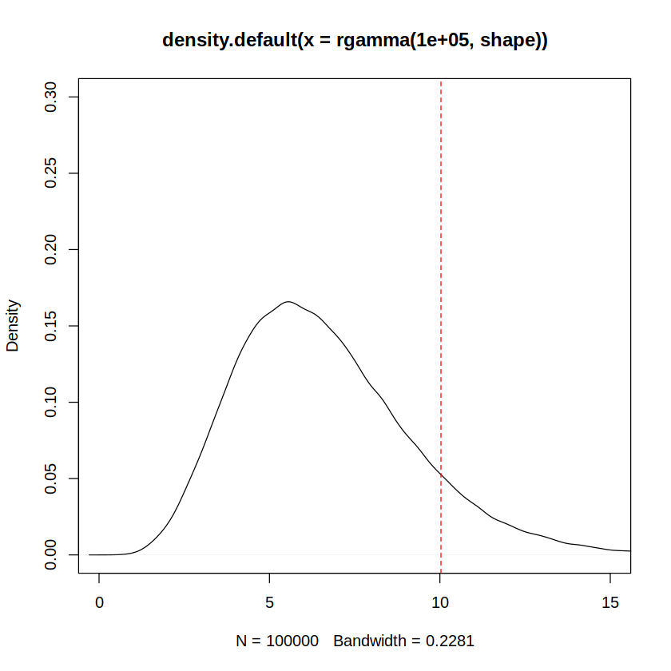

```r
shape <- 6.6
plot(density(rgamma(100000, shape)), xlim=c(0,15), ylim=c(0, 0.3))
abline(v=qgamma(.9, shape), col="red", lty="dashed")
```

# Just Scratching the Surface

- "Modern" R with pipes, the [tidyverse](https://www.tidyverse.org/), and ggplot2
- Functional Programming with `*apply` and `purrr`.
- Macros
- OOP with R's 3 different class systems
- Web Scraping
- ...and more!

# The End, Questions?

[figure not shown]

https://github.com/joshkunz/2022-r-hacker-refactor-presentation

Configuration

```r
# Need to do this because the SVG graphs were not rendering properly in the HTML slides.
options(jupyter.plot_mimetypes = c("text/plain", "image/png" ))
```